# nwi_article_charts

RJL

2026-02-12

### Older Americans tend to have more nonwage income.

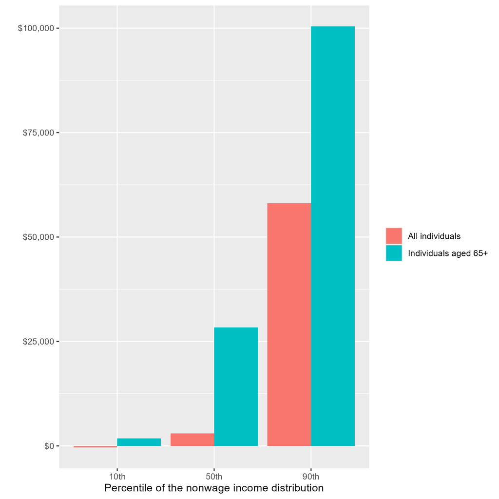

Figure 2

Source: IDDA, 2023 data. Individuals in this case refers to the population of U.S. tax filers. Nonwage income is measured at the household level. Percentiles are calculated across individuals; when calculating percentiles we assign each individual the value of the household nonwage income per filing adult in the household. Values are nominal.

### The majority of nonwage income is in dividends, S-corporation, and capital gains income, especially for the rich.

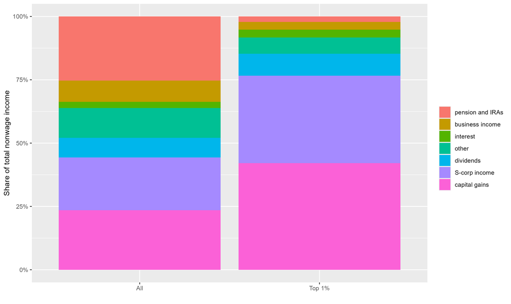

Figure 3

Source: IRS, 2022 Statistics of Income. “All” refers to all U.S. tax filers with positive adjusted gross income. Top 1% is in reference to adjusted gross income (AGI).

### As individuals age, wages fall while nonwage income rises.

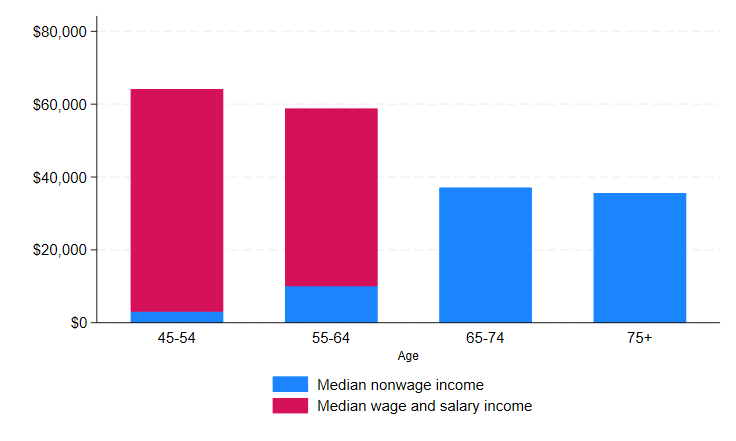

Figure 4

Source: HRS, pooled data from year 2000 onwards. Nonwage income refers to taxable nonwage components, such as pensions, social security, financial income such as interest and dividends, business and self-employment income, disability insurance and unemployment insurance income. NOnwage income is by household. Median is calculated across all household heads (oldest member of household). Values are normalized to 2022 dollars before calculating median.

### Income-poor older households tend to rely almost entirely on nonwage income, while income-rich older households rely on it less.

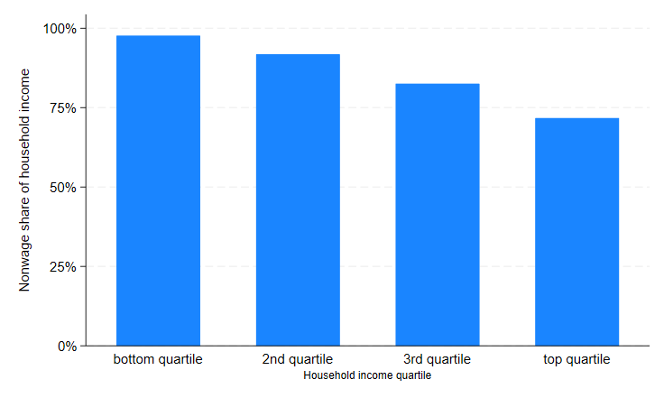

Figure 5

Source: HRS, pooled data from year 2000 onwards, households where the oldest member is 65+ years of age. Bars represent the average nonwage share of household income for individuals in the 1st (bottom) to 4th (top) household income quartiles.

### Income-rich older households are more likely to be working.

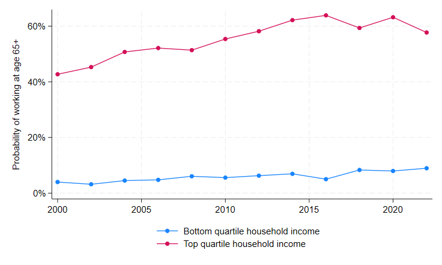

Figure 6

Source: HRS, pooled data from year 2000 onwards, households where the oldest member is 65+ years of age. Lines represent the proportion of households which receive positive wage and salary income.

### White retirees receive more nonwage income after retiring than Black or Hispanic retirees after controlling for pre-retirement wages.

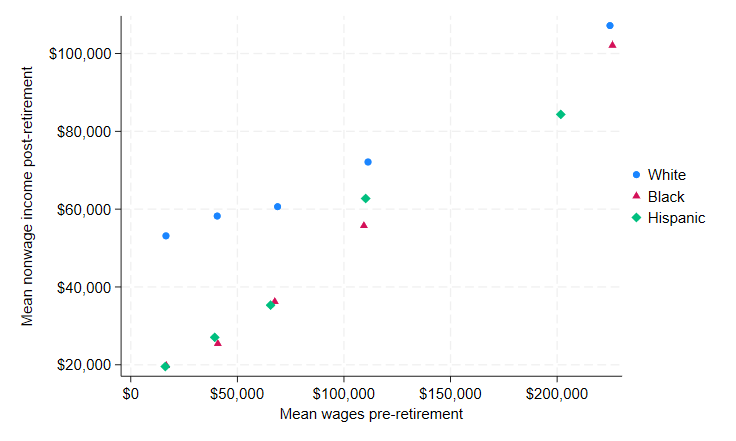

Figure 7

Source: HRS wave 5+, individuals must be observed for 6 periods centered around retirement. Mean earnings must be above $5,000 in pre-retirement. Each point represents the group mean, conditional on being in the 1st (bottom) to 5th (top) quintile of mean pre-retirement ages across all groups.

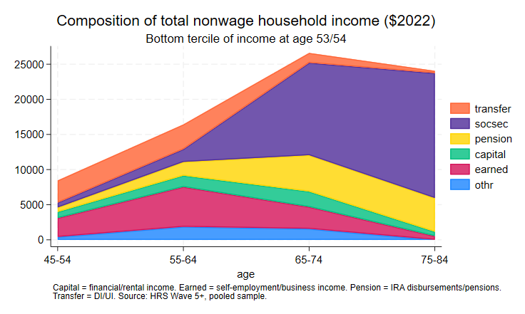

Data dive graphs

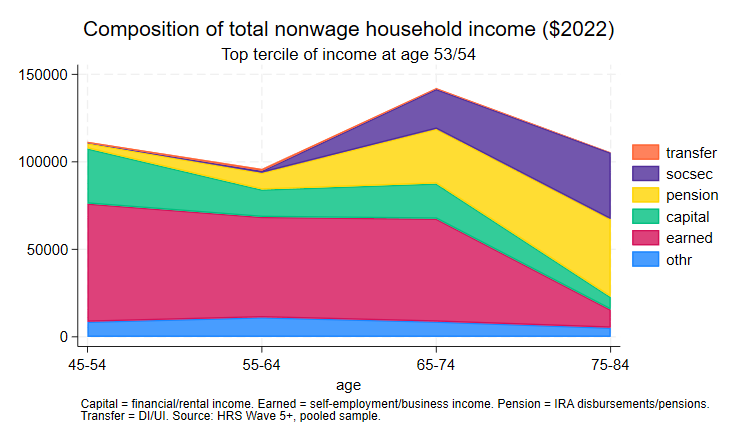

Data dive graphs